# NEU 290 Data Assignment 4

# Temporal Rate Perception

For this second section, you will look at data from an experiment designed to help understand the perception of *rate*: When we perceive things as happening fast or slow, are our perceptions warped by our recent experience with fast things or slow things? If you listen to musical rhythms that are really fast, are you more likely to interpret a new rhythm as faster because you are primed to interpret things as fast (we can call this the priming hypothesis)? Or, after listening to a fast rhythm will you perceive new rhythms as *slower* than they really are, because you’ve adapted to thinking that fast is normal (we can call this the adaptation hypothesis)? In this section, you’ll use linear regression to try to answer these kinds of questions.

## Acquire Data

```r
id <- '1xhJ8kFIcYGI9hHFT2k2s2UFHCvtXNXLN'
timing_data <- read.csv(sprintf("https://docs.google.com/uc?id=%s&export=download", id))
```

## Explore Data

```r
glimpse(timing_data)
```

```
## Rows: 150
## Columns: 3
## $ X            <int> 1, 2, 3, 4, 5, 6, 7, 8, 9, 10, 11, 12, 13, 14, 15, 16, 17…
## $ ExposureRate <chr> "Fast", "Slow", "Slow", "Baseline", "Fast", "Fast", "Base…
## $ ProducedRate <dbl> 370.96, 283.82, 265.24, 348.74, 408.26, 423.38, 364.37, 3…
```

This data includes responses from a single participant on 150 trials of an experiment. In each trial, the participant first listened to a rhythm that repeated every 333 ms (a “baseline” rhythm), or they listened to a rhythm that repeated every 666 ms (a “slow” rhythm), or they listened to a rhythm that repeated every 166.6 ms (a “fast” rhythm). After the participant was exposed to any of these rhythms for 20 repetitions, the participant was present a single repetition of a 333 ms rhythm. The participant was asked to repeat that 333 ms rhythm ten times by tapping their finger. The average rate (in ms) that the participant tapped the rhythm is recorded as ProducedRate. ExposureRate tells you if the participant listened to a baseline (333 ms), fast (166.6 ms), or slow (666 ms) rhythm. For this study, the ProducedRate is our way to measure the participants *perception* of the test 333 ms rhythm. If the participant taps faster than 333 ms (less than 333 ms) then the participant perceives the rhythm as faster than it really is; if the participant taps slower than 333 ms (more than 333 ms), then the participant perceives the rhythm slower than it really is.

## Model the data

Now, use linear models to see if the data that we have is more consistent with the priming hypothesis (that fast exposure will lead to faster perception and slow exposure will lead to slower perception) or more consistent with the adaptation hypothesis (that fast exposure will lead to slower perception and that slow exposure will leader to faster perception). We will want to see how average RateProduced depends on RateExposure!

### Exercise 7: Visualize Timing Data

To start with, create a visualization to help us understand out data! Make sure that it is an appropriate visualization to compare RateProduced across levels of RateExposure.

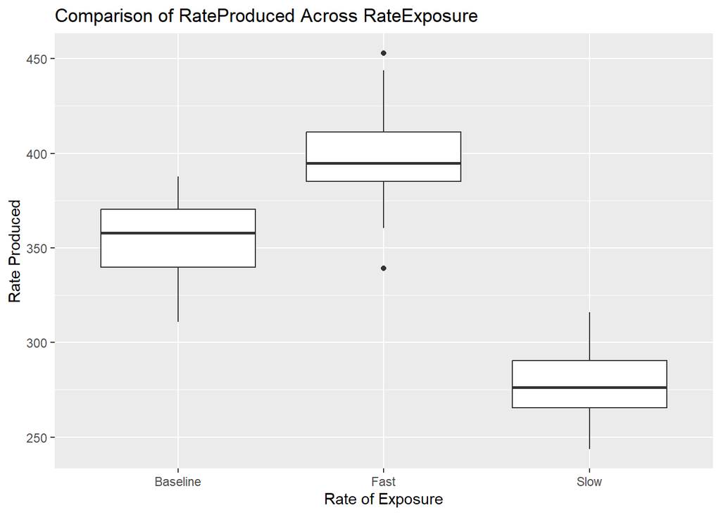

```r
timing_data %>%
  ggplot(aes(x = ExposureRate, y = ProducedRate)) +
  geom_boxplot() +
  labs(title = "Comparison of RateProduced Across RateExposure",
       x = "Rate of Exposure",
       y = "Rate Produced")
```

### Exercise 8: Model Timing Data

Now, fit a linear model to help us understand how perception of rate might differ based on prior exposure to different rates. Show the coefficient values for this model.

```r
TimingModel <-lm(ProducedRate ~ ExposureRate, data = timing_data)
get_regression_table(TimingModel)
```

```
## # A tibble: 3 × 7
##   term               estimate std_error statistic p_value lower_ci upper_ci
##   <chr>                 <dbl>     <dbl>     <dbl>   <dbl>    <dbl>    <dbl>
## 1 intercept             356.       2.79     128.        0    350.     361.
## 2 ExposureRate: Fast     41.3      3.94      10.5       0     33.5     49.1
## 3 ExposureRate: Slow    -79.0      3.94     -20.0       0    -86.8    -71.2
```

### Exercise 9: Interpret Model

Based on the model above, interpret the data!

Choose the correct interpretation by deleting the statement below that is false: * The data is more consistent with the **adaptation** hypothesis were perception is - *slower* after being exposed to fast rhythms.

Replace the …s below with the correct values: * The average (mean) rate produced by the participant in the fast condition is 355.594 + 41.331 = 396.925 ms. * The average (mean) rate produced by the participant in the baseline condition is 355.594 ms.

# That’s all for now!

Knit this markdown file as an html and submit on Canvas!